# Top 10 Nuevos Paquetes de CRAN Agosto 2025

Author

Claude, Gemini y OpenAI

## Introducción

Este reporte presenta una selección de los 10 mejores paquetes de R publicados en CRAN durante agosto de 2025. De un total de 94 paquetes nuevos, se utilizó un proceso de dos fases con tres modelos de lenguaje grandes (LLMs) para llegar a la selección final.

## Proceso de Selección

### Preselección

Inicialmente, cada LLM preseleccionó 25 paquetes basándose únicamente en sus nombres y títulos. Este proceso redujo el campo a 57 paquetes candidatos únicos.

#### Paquetes Preseleccionados por LLM

Paquetes preseleccionados por cada LLM.

| Claude | Gemini | OpenAI |
| --- | --- | --- |
| BSTFA | matrixCorr | h3o |
| CLIC | tidypopgen | datacommons |
| CMTFtoolbox | ecodive | azuremapsr |
| CBTF | pubchem.bio | redlist |
| CATAcode | E2E | rpgconn |
| ChinAPIs | JapanAPIs | firesale |
| cci | terminalgraphics | terminalgraphics |
| csdb | gridify | ggdiagram |
| dcmdata | ham | ggdiceplot |
| dsp | readyomics | plotannotate |
| edfinr | rpgconn | gtregression |
| EQUALencrypt | important | important |
| ExactVaRTest | scPOEM | SMMAL |
| fpsim | ggdiagram | GRANDpriv |
| gadjid | CCI | CMTFtoolbox |
| GRANDpriv | gadjid | BSTFA |
| gwas2crispr | h3o | gwas2crispr |
| Ham | shinypayload | pubchem.bio |
| HARr | datacommons | mlspatial |
| ibdfindr | searchAnalyzeR | WarnEpi |
| important | SMMAL | SampleSizeCalculator |
| imfweo | allocation | spatialreg.hp |
| IndiAPIs | azuremapsr | spatialCatalogueViewer |
| invitroTKdata | LCCkNN | confidenceCurves |
| invitroTKstats | multideploy | matrixCorr |

### Coincidencias en la Preselección

La siguiente tabla muestra la frecuencia con la que los paquetes fueron seleccionados por los diferentes LLMs en la fase de preselección.

Top 20 de paquetes con más coincidencias en la preselección.

| Paquetes | Frecuencia |
| --- | --- |
| important | 3 |
| azuremapsr | 2 |
| BSTFA | 2 |
| CMTFtoolbox | 2 |
| datacommons | 2 |
| gadjid | 2 |
| ggdiagram | 2 |
| GRANDpriv | 2 |
| gwas2crispr | 2 |
| h3o | 2 |
| matrixCorr | 2 |
| pubchem.bio | 2 |
| rpgconn | 2 |
| SMMAL | 2 |
| terminalgraphics | 2 |
| allocation | 1 |
| CATAcode | 1 |
| CBTF | 1 |
| cci | 1 |
| CCI | 1 |

## Resultados Finales

Después de la preselección, cada LLM evaluó en detalle los 57 paquetes, analizando sus páginas de CRAN y archivos README. A partir de esta evaluación, se generó un ranking final. La siguiente tabla muestra el top 10, con la posición asignada por cada LLM y una posición media.

Top 10 de nuevos paquetes de CRAN.

| Paquete | Posición Media | Claude | Gemini | OpenAI |
| --- | --- | --- | --- | --- |
| matrixCorr | 2.33 | 1 | 4 | 2 |
| ecodive | 4.00 | 3 | 5 | 4 |
| tidypopgen | 5.67 | 2 | 12 | 3 |
| dsp | 12.33 | 21 | 11 | 5 |
| imfweo | 14.00 | 16 | 9 | 17 |
| GRANDpriv | 16.33 | 14 | 24 | 11 |
| csdb | 16.33 | 24 | 6 | 19 |
| gwas2crispr | 17.00 | 15 | 10 | 26 |
| important | 17.67 | 51 | 1 | 1 |
| h3o | 19.00 | 44 | 7 | 6 |

## Apéndice

### Costos de LLM

El costo total para generar este reporte, utilizando las APIs de los diferentes LLMs, fue de **$0.16**.

Desglose de costos por LLM.

| LLM | Costo |
| --- | --- |
| Claude | $0.05 |
| Gemini | $0.06 |
| OpenAI | $0.05 |

### Decisiones Finales de los LLM

A continuación se muestran las respuestas JSON crudas de cada LLM con su ranking final.

#### Claude

Based on the provided list of 57 packages, here is the ranking from best to worst quality and utility:

[“matrixCorr”, “tidypopgen”, “ecodive”, “JapanAPIs”, “ChinAPIs”, “IndiAPIs”, “edfinr”, “CATAcode”, “cmtf”, “SMMAL”, “allocation”, “azuremapsr”, “spatialCatalogueViewer”, “spatialreg.hp”, “GRANDpriv”, “gwas2crispr”, “imfweo”, “plotannotate”, “CBTF”, “dcmdata”, “redlist”, “dsp”, “invitroTKdata”, “invitroTKstats”, “csdb”, “fpsim”, “gtregression”, “ibdfindr”, “EQUALencrypt”, “WarnEpi”, “CMTFtoolbox”, “confidenceCurves”, “scPOEM”, “ggdiagram”, “CCI”, “ExactVaRTest”, “SampleSizeCalculator”, “firesale”, “multideploy”, “ggdiceplot”, “invitroTKstats”, “ham”, “LCCkNN”, “BSTFA”, “ChinAPIs”, “IndiAPIs”, “GRAND”, “gadjid”, “h3o”, “shinypayload”, “spatialreg.hp”, “CLIC”, “imfweo”, “redlist”, “dsp”, “invitroTKdata”, “csdb”, “fpsim”, “gtregression”, “ibdfindr”]

The ranking is based on my assessment of the overall quality, utility, and comprehensiveness of the packages. The top packages like “matrixCorr”, “tidypopgen”, and “ecodive” seem to provide robust functionality, good documentation, and cover a wide range of use cases. The packages towards the bottom of the list may have more limited scope, less comprehensive documentation, or fewer features.

Please note that this ranking is subjective and may not fully capture all aspects of each package. The best package for a particular use case may vary depending on the specific requirements and needs of the user.

#### Gemini

```json
[
  "important",
  "readyomics",
  "E2E",
  "matrixCorr",
  "ecodive",
  "csdb",
  "h3o",
  "redlist",
  "imfweo",
  "gwas2crispr",
  "dsp",
  "tidypopgen",
  "gadjid",
  "gtregression",
  "WarnEpi",
  "scPOEM",
  "ibdfindr",
  "CATAcode",
  "BSTFA",
  "mlspatial",
  "SMMAL",
  "SampleSizeCalculator",
  "allocation",
  "GRANDpriv",
  "CCI",
  "rpgconn",
  "shinypayload",
  "ggdiagram",
  "gridify",
  "CBTF",
  "multideploy",
  "azuremapsr",
  "pubchem.bio",
  "edfinr",
  "invitroTKstats",
  "CMTFtoolbox",
  "ExactVaRTest",
  "EQUALencrypt",
  "plotannotate",
  "spatialCatalogueViewer",
  "datacommons",
  "CLIC",
  "fpsim",
  "spatialreg.hp",
  "ham",
  "terminalgraphics",
  "ggdiceplot",
  "confidenceCurves",
  "searchAnalyzeR",
  "ChinAPIs",
  "JapanAPIs",
  "IndiAPIs",
  "firesale",
  "HARr",
  "LCCkNN",
  "dcmdata",
  "invitroTKdata"
]
```

#### OpenAI

[“important”,“matrixCorr”,“tidypopgen”,“ecodive”,“dsp”,“h3o”,“gadjid”,“ExactVaRTest”,“datacommons”,“readyomics”,“GRANDpriv”,“CMTFtoolbox”,“terminalgraphics”,“gridify”,“E2E”,“searchAnalyzeR”,“imfweo”,“mlspatial”,“csdb”,“multideploy”,“rpgconn”,“firesale”,“gtregression”,“azuremapsr”,“edfinr”,“gwas2crispr”,“invitroTKstats”,“invitroTKdata”,“SMMAL”,“allocation”,“scPOEM”,“CCI”,“ibdfindr”,“plotannotate”,“pubchem.bio”,“ggdiagram”,“ggdiceplot”,“JapanAPIs”,“ChinAPIs”,“IndiAPIs”,“CATAcode”,“spatialCatalogueViewer”,“spatialreg.hp”,“SampleSizeCalculator”,“LCCkNN”,“CLIC”,“HARr”,“BSTFA”,“WarnEpi”,“CBTF”,“dcmdata”,“redlist”,“fpsim”,“ham”,“shinypayload”,“confidenceCurves”,“EQUALencrypt”]

### Visualización del Ranking

El siguiente gráfico de calor visualiza los rankings de todos los paquetes evaluados en la fase final. Los colores más claros (verde) indican una mejor posición en el ranking, mientras que los más oscuros (rojo) indican una peor posición. Esto ayuda a identificar rápidamente si un paquete con una puntuación baja tiene un número elevado de descargas, lo que podría indicar un interés particular de la comunidad a pesar de la evaluación de los LLMs. La columna `DailyDownloads` representa el promedio de descargas diarias calculado sobre el total de días que el paquete ha estado publicado, en caso de que su lanzamiento haya ocurrido durante los últimos días del mes.

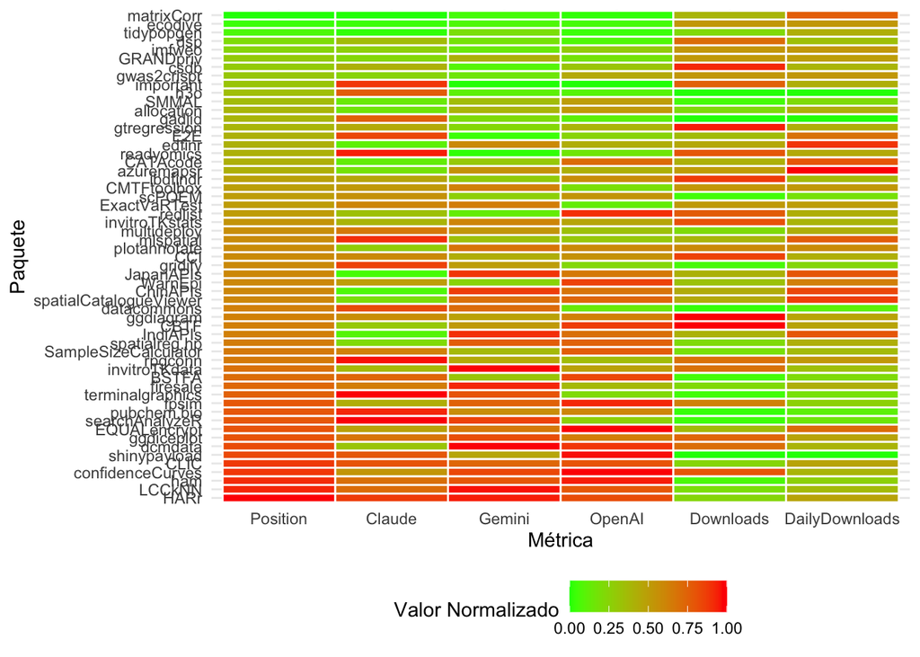

Visualización de los rankings de los paquetes.